# Introduction to Data Science with R

by Luke Henke

First, include the graphics library we will use the rest of the time. Also, set a random seed so the results are reproducable.

```r
library(ggplot2)
set.seed(1)
```

# Regression

Regression seeks to understand the relationship between a **dependent variable** and one or more **independent variables** (i.e. ‘features’).

This typically used for **prediction** or **forecasting**, as once we fit (i.e. ‘train’) a model, we can use that to predict future results.

## Simple Linear Regression

We’ll start here, as most of you either have, or will, see this in MATH201 (or another introductory statistics course). For simple linear regression, we’ll restrict ourselves to models that have **one** feature/independent variable, with a **linear** trend.

The idea is simple: we have some data.

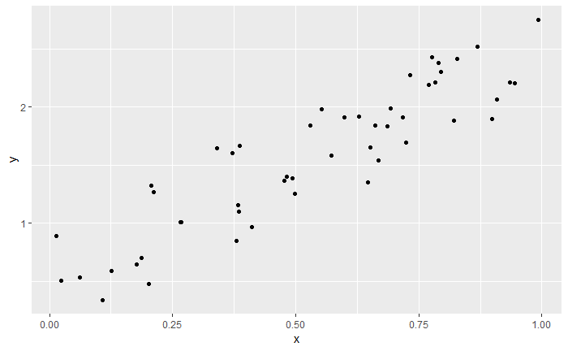

```r
x = runif(50) # Generate 50 random data points from a uniform distribution
y = 2*x + runif(50)
qplot(x = x, y = y)
```

It looks vaguely linear, so we want to fit a linear line, or a “line of best fit.”

To be formal, we are trying to find $\hat{\beta_1}$ and $\hat{\beta_0}$ such that the line:

$$y = \hat{\beta_0} + \hat{\beta_1} \cdot x$$

fits the data the best.

To do this, we will use the `lm` command, short for ‘linear model’.

```r
# When we save the model to a variable, R doesn't output anything
model = lm(y ~ x)
# Explicitely ask for the coefficients
model$coefficients
```

```
(Intercept)           x
  0.4750442   2.0526802
```

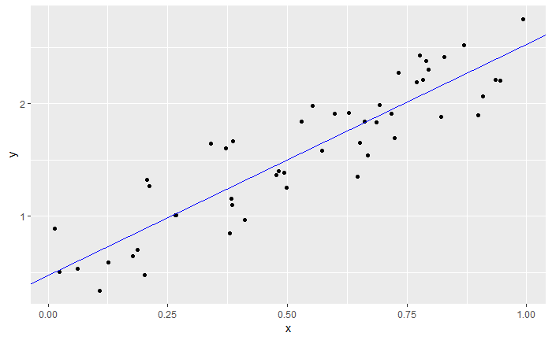

```r
# Add a line to the graph (R uses 1-based indexing, unfortunately)
qplot(x = x, y = y) +
    geom_abline(slope = model$coefficients[2], intercept = model$coefficients[1], color = 'Blue')
```

Now, you might be asking “how does it calculate these coefficients?”

The answer: Calculus and/or Linear Algebra (For those that want to see a full derivation, either take MATH424, or read [this blog post](https://ivanky.wordpress.com/2018/05/20/derivation-of-simple-linear-regression-formula/). The basic idea is to take partial derivates and set them equal to 0.).

For simple linear regression, there are nice, closed-form solutions for both $\hat{\beta_1}$ and $\hat{\beta_0}$.

$$\hat{\beta_1} = \dfrac{\sum_{i=1}^{n}\left[(x_i - \bar{x})(y_i - \bar{y})\right]}{\sum_{i=1}^{n}\left[(x_i - \bar{x})^2\right]}$$

$$\hat{\beta_0} = \bar{y} - \hat{\beta_1} \bar{x}$$

R isn’t actually calculating the coefficients this way, but at least it provides insight into how “machine learning” is really just statistics. (R performs a QR decomposition on the design matrix, $X$, and uses backsubstitution to find $\hat{\mathbf{\beta}}$)

### Measuring Goodness of Fit

Now, at this point you’re probably wondering how *good* this line fits. There’s a couple measurements, the first one is `r`, or the **correlation** coefficient.

$$r = \dfrac{1}{n - 1} \sum_{i=1}^n \left( \dfrac{x_i - \bar{x}}{s_x} \right) \left(\dfrac{y_i - \bar{y}}{s_y} \right)$$

A good way to think of this formula is that we’re trying to see if $x$ and $y$ vary together: does a larger z-score in $x$ *also* mean a larger z-score in $y$?

As usual, `R` has a function for this.

```r
cor(x, y)
```

```
[1] 0.9039356
```

For various reasons, we don’t use $r$ (one of them being that correlation is undefined for more than 1 feature), but rather $r^2$ (which can be calculated a totally different way).

$$r^2 = \dfrac{\sum_{i=1}^n(y_i - \bar{y})^2 - \sum_{i=1}^n(y_i - \hat{y_i})^2}{\sum_{i=1}^n(y_i - \bar{y})^2}$$

This formula measures how “good” our prediction is compared to simply predicting the average ($\bar{y}$). We obviously hope our machine-learning does better than merely predicting the average, but sometimes that isn’t the case!

Showing that squaring the first equation yields the second equation requires quite a bit of math, but it can be done.

The linear model calculates this for us.

```r
summary(model)$r.squared
```

```
[1] 0.8170995
```

Notice:

```r
cor(x, y)^2
```

```
[1] 0.8170995
```

```r
summary(model)$r.squared
```

```
[1] 0.8170995
```

### Extensions

There are some obvious extensions to our simple linear regression model, such as: * More than one feature (e.g. more $x$s), this is called **multiple regression** * Non-linear relationships (we will see a similar idea later with kernels)

We won’t cover these, as Support Vector Machines (next) are much cooler, and I wanted to spend more time on them.

# Support Vector Machines

Support Vector Machines (SVMs) are a type of **supervised learning** algorithm that tries to *classify* data.

The basic idea is that the model tries to classify a new example into one of two **groups** (or **categories**). For SVMs, this is done by creating a boundary that separates the two datasets. The formal mathematical term is that SVMs are a “non-probabilistic binary linear classifier”.

## Linear Separation

To begin, we will build a model that separates data by dividing each with a linear line.

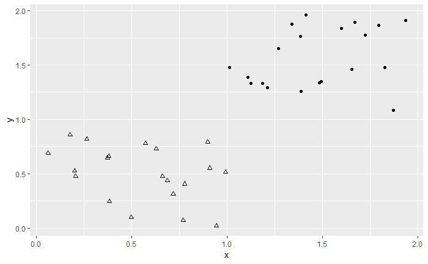

```r
set.seed(1)
x = matrix(runif(40 * 2), ncol = 2)
y = c(rep(-1, 20), rep(1,20))
x[y==1,] = x[y==1,] + 1
group_one = data.frame(x = x[y==1, 1], y = x[y==1, 2])
group_two = data.frame(x = x[y!=1, 1], y = x[y!=1, 2])
ggplot(group_one, aes(x, y)) +
    geom_point() +
    geom_point(data = group_two, shape = 2)
```

Obviously, the two categories can be separated by a linear line and this can easily be done by hand. But an issue is that there are *many* linear lines that can separate the data!

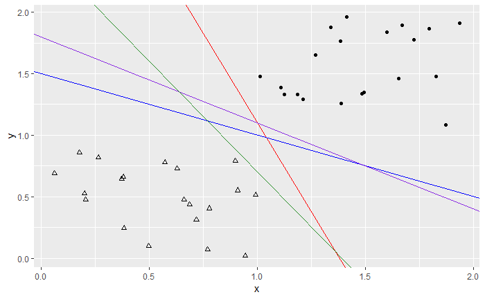

```r
library(e1071)
ggplot(group_one, aes(x, y)) +
    geom_point() +
    geom_point(data = group_two, shape = 2) +
    geom_abline(intercept = 4, slope = -2.9, color = 'Red') +
    geom_abline(intercept = 1.5, slope = -0.5, color = 'Blue') +
    geom_abline(intercept = 1.8, slope = -0.7, color = 'blueviolet') +
    geom_abline(intercept = 2.5, slope = -1.8, color = 'forestgreen')
```

The solution to this adding a metric: the **margin**, which is the minimum distance from a point to the boundary. Therefore, we define the **maximum marginal classifier**: the separating line that maximizes the margin.

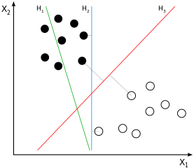

This also leads us to the terminology of a **support vector**: a data point that lies on the margin! In the figure above, there are *two* support vectors for $H_3$ (which is the maximum marginal classifier).

A *lot* of math goes into finding the maximum marginal classifier, this is not a simple problem!

After doing quite a fair bit of math (including deriving an extension to the method of Lagrange Multipliers that is taught in Calc 3), we end up wanting to maximize the **dual problem**:

$$D(\alpha) = \sum_{i=1}^{m} \alpha_i - \dfrac{1}{2}\sum_{i=1}^{m}\sum_{j=1}^{n}\alpha_i \alpha_j y_i y_j \vec{x}_i^T \vec{x}_j$$

subject to $\alpha_i \geq 0$ for all $i$, and $\sum_{i=1}^{m}\alpha_i y_i = 0$

But, you don’t care about all this math! There’s a command that will do it for us: `svm()`

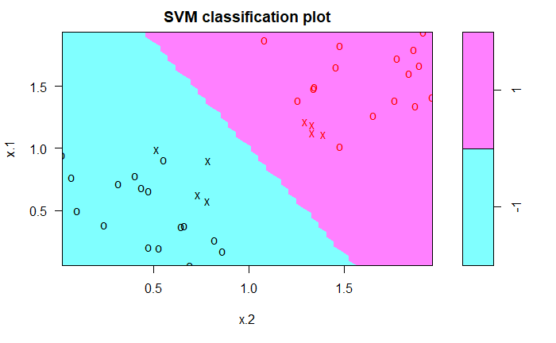

```r
dat = data.frame(x=x, y=as.factor(y))
svmmodel = svm(y ~ ., data = dat, kernel="linear", cost = 1, scale = FALSE)
plot(svmmodel, data = dat)
```

## Non-Separable Data Set

While this is nice and all, most data sets are *not* perfectly separable, as illustrated below.

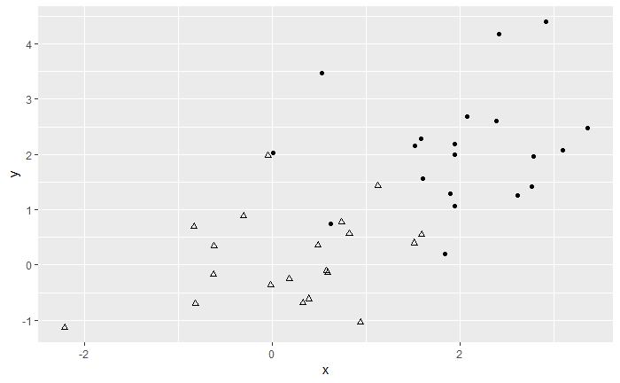

```r
set.seed(1)
x = matrix(rnorm(40 * 2), ncol = 2)
y = c(rep(-1, 20), rep(1, 20))
x[y==1,] = x[y==1,] + 2
group_one = data.frame(x = x[y==1, 1], y = x[y==1, 2])
group_two = data.frame(x = x[y!=1, 1], y = x[y!=1, 2])
ggplot(group_one, aes(x, y)) +
    geom_point() +
    geom_point(data = group_two, shape = 2)
```

This is actually pretty easy to account for: we simply update our optimization method by adding the [KKT conditions](https://en.wikipedia.org/wiki/Karush-Kuhn-Tucker_conditions) (don’t worry about that, the `svm()` command does this for us)

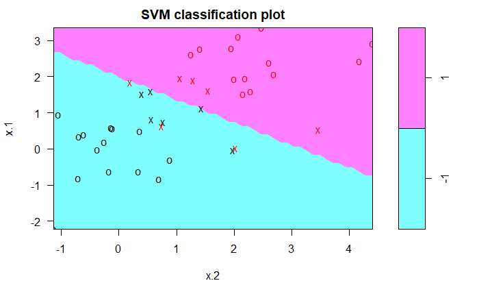

```r
dat = data.frame(x=x, y=as.factor(y))
svmmodel = svm(y ~ ., data = dat, kernel="linear", cost = 1, scale = FALSE)
plot(svmmodel, data = dat)
```

This is also useful for data sets that *are* linearly separable, but where the maximal margin classifier (i.e. perfectly separating the datasets) may not be the best.

## Non-Linear Separators

Everything we’ve done so far has been for linear boundaries. What about datasets that are *not* separated by a linear boundary?

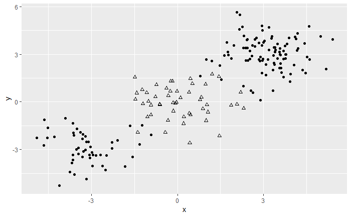

```r
set.seed(1)
x = matrix(rnorm(200 * 2), ncol = 2)
x[1:100, ] = x[1:100, ] + 3
x[101:150, ] = x[101:150, ] - 3
y = c(rep(1, 150), rep(2, 50))
group_one = data.frame(x = x[y==1, 1], y = x[y==1, 2])
group_two = data.frame(x = x[y!=1, 1], y = x[y!=1, 2])
ggplot(group_one, aes(x, y)) +
    geom_point() +
    geom_point(data = group_two, shape = 2)
```

We fix this by applying something that’s called the **kernal trick**. Basically, we make a non-linear transformation of the data before handing it to our optimization algorithm. Everytime we have the inner product between $x$ and $x_i$, we replace it with the kernal $K(x,x_i)$.

For example:

1. Linear Kernal (no change to the inner product)
   $$K(x_i, x_{i'}) = \sum_{j=1}^p x_{ij} x_{i'j}$$
2. Polynomial Kernal (of degree $d$)
   $$K(x_i, x_{i'}) = (1 + \sum_{j=1}^p x_{ij} x_{i'j})^d$$
3. Radial Kernel
   $$K(x_i, x_{i'}) = \exp(-\gamma \sum_{j=1}^p (x_{ij} x_{i'j})^2)$$

The `svm()` command supports kernels (as you likely noticed previously, we were telling it a linear kernal), along with the extra parameters needed to run the kernel. (For instance, $\gamma$ for the radial kernel.)

This is where the Data Science part comes in: what parameters to use? While there are functions (such as `tune()`) that can help with this (by performing something called cross validation), at the end of the day, it is the data scientist that decides what parameters to use.

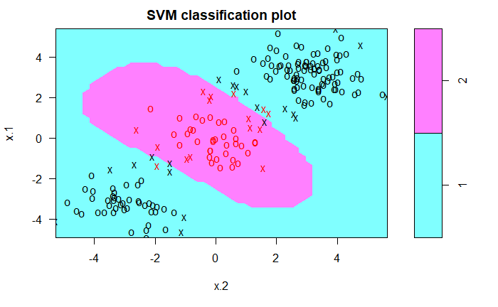

```r
dat = data.frame(x=x, y=as.factor(y))
svmfit = svm(y ~ ., data = dat, kernel="radial", gamma = 1, cost = 1)
plot(svmfit, dat)
```

# Further Reading

*Obviously* there is a lot more to learn, even about the things I covered!

Here’s some classes at Mines that cover these and similar concepts:

- MATH437 (Statistical Learning)
- CSCI303 (Data Science)
- CSCI470 (Machine Learning)

Also, there’s some phenomonal textbooks:

- The online [Python Data Science Handbook](https://jakevdp.github.io/PythonDataScienceHandbook/index.html)
- [An Introduction to Statistical Learning](https://www.springer.com/gp/book/9781461471370) (You can get this one for free, online, through the Mines Library!)
- [The Elements of Statistical Learning](https://www.springer.com/gp/book/9781461471370) (also available through the library for free)

# Credits

The linear regression part was inspired from the Python Data Science Handbook, and the SVM section was inspired from the SVM R Lab from Chapter 9 of An Introduction to Statistical Learning.